# Module 3

YiWei Yang (18422148)

April 24, 2018

### Problem set_04 “Fine-scale phylogenetic architecture”

#### Learning objectives:

- Gain experience estimating diversity within a hypothetical microbial community

#### Outline:

In class Day 1:

1. Define and describe species within your group’s “microbial” community.
2. Count and record individuals within your defined species groups.
3. Remix all species together to reform the original community.
4. Each person in your group takes a random sample of the community (*i.e.* devide up the candy).

Assignment:

5. Individually, complete a collection curve for your sample.
6. Calculate alpha-diversity based on your original total community and your individual sample.

In class Day 2:

7. Compare diversity between groups.

#### Part 1: Description and enumeration

1. Construct a table listing each species, its distinguishing characteristics, the name you have given it, and the number of occurrences of the species in the collection.

```r
#To make tables
library(kableExtra)
library(knitr)
#To manipulate and plot data
library(tidyverse)
example_data3=data.frame(
  number = c(1,2,3,4,5,6,7,8,9,10,11,12,13,14,15,16,17,18,19,20,21,22,23,24,25,26,27,28,29,30,31,32,33,34,35,36,37,38,39,40,41,42,43,44,45,46,47,48),
  name = c("RIGOA", "RIGOA", "RIGOA","RIGOA","RIGOA","Skittles","Skittles","Skittles","Skittles","Skittles","M&M","M&M","M&M","M&M","M&M","M&M","Mikes & Ike's","Mikes & Ike's","Mikes & Ike's","Mikes & Ike's","Mikes & Ike's","Gummy Bears","Gummy Bears","Gummy Bears","Gummy Bears","Gummy Bears","Gummy Bears","LEGO","LEGO","LEGO","LEGO","LEGO","LEGO","LEGO","Gumdrops","Gumdrops","Gumdrops","Gumdrops","Gumdrops","Fruit shaped gummies (gold)","MACROPHAGE","COKE BOTTLES","BLUE WHITE DROP","RED WHITE DROP","WATERMELON","RED GREEN FISH","KISSES","RED SNAKES"),
  characteristics = c("Maroon", "Yellow", "Translucent","Orange","Brown","Brown","Yellow","Red","Orange","Green","Brown","Red","Green","Blue","Orange","Yellow","Yellow","Pink","Red","Green","Orange","Pink","Red","Green","Orange","Yellow","Translucent yellow","Blue square","Blue rectangle","Green rectangle","Yellow square","Yellow rectangle","Pink square","Pink rectangle","Brownish purple","Red","Green","Orange","Yellow","Fruit shaped gummies (gold)","MACROPHAGE","COKE BOTTLES","BLUE WHITE DROP","RED WHITE DROP","WATERMELON","RED GREEN FISH","KISSES","RED SNAKES"),
  occurences = c(2,1,2,1,1,37,35,43,37,45,30,28,24,39,65,32,45,44,41,39,30,17,11,17,15,17,14,1,3,2,1,4,1,6,3,7,5,5,4,2,6,3,2,1,1,1,16,13)
)

example_data3 %>%
  kable("html") %>%
  kable_styling(bootstrap_options = "striped", font_size = 10, full_width = F)
```

| number | name | characteristics | occurences |
| --- | --- | --- | --- |
| 1 | RIGOA | Maroon | 2 |
| 2 | RIGOA | Yellow | 1 |
| 3 | RIGOA | Translucent | 2 |
| 4 | RIGOA | Orange | 1 |
| 5 | RIGOA | Brown | 1 |
| 6 | Skittles | Brown | 37 |
| 7 | Skittles | Yellow | 35 |
| 8 | Skittles | Red | 43 |
| 9 | Skittles | Orange | 37 |
| 10 | Skittles | Green | 45 |
| 11 | M&M | Brown | 30 |
| 12 | M&M | Red | 28 |
| 13 | M&M | Green | 24 |
| 14 | M&M | Blue | 39 |
| 15 | M&M | Orange | 65 |
| 16 | M&M | Yellow | 32 |
| 17 | Mikes & Ike’s | Yellow | 45 |
| 18 | Mikes & Ike’s | Pink | 44 |
| 19 | Mikes & Ike’s | Red | 41 |
| 20 | Mikes & Ike’s | Green | 39 |
| 21 | Mikes & Ike’s | Orange | 30 |
| 22 | Gummy Bears | Pink | 17 |
| 23 | Gummy Bears | Red | 11 |
| 24 | Gummy Bears | Green | 17 |
| 25 | Gummy Bears | Orange | 15 |
| 26 | Gummy Bears | Yellow | 17 |
| 27 | Gummy Bears | Translucent yellow | 14 |
| 28 | LEGO | Blue square | 1 |
| 29 | LEGO | Blue rectangle | 3 |
| 30 | LEGO | Green rectangle | 2 |
| 31 | LEGO | Yellow square | 1 |
| 32 | LEGO | Yellow rectangle | 4 |
| 33 | LEGO | Pink square | 1 |
| 34 | LEGO | Pink rectangle | 6 |
| 35 | Gumdrops | Brownish purple | 3 |
| 36 | Gumdrops | Red | 7 |
| 37 | Gumdrops | Green | 5 |
| 38 | Gumdrops | Orange | 5 |
| 39 | Gumdrops | Yellow | 4 |
| 40 | Fruit shaped gummies (gold) | Fruit shaped gummies (gold) | 2 |
| 41 | MACROPHAGE | MACROPHAGE | 6 |
| 42 | COKE BOTTLES | COKE BOTTLES | 3 |
| 43 | BLUE WHITE DROP | BLUE WHITE DROP | 2 |
| 44 | RED WHITE DROP | RED WHITE DROP | 1 |
| 45 | WATERMELON | WATERMELON | 1 |
| 46 | RED GREEN FISH | RED GREEN FISH | 1 |
| 47 | KISSES | KISSES | 16 |
| 48 | RED SNAKES | RED SNAKES | 13 |

2. Ask yourself if your collection of microbial cells from seawater represents the actual diversity of microorganisms inhabiting waters along the Line-P transect. Were the majority of different species sampled or were many missed?

No, my sample of microbial cells do not represent the actual diversity of microorganisms for the entire community inhabiting waters along the Line-P transect. Majority of different species were sampled, but some were missed and the proportional of different species does not accurately represent the original proportional of species in the original community

#### Part 2: Collector’s curve

For your sample:

- Create a collector’s curve for your sample (not the entire original community).

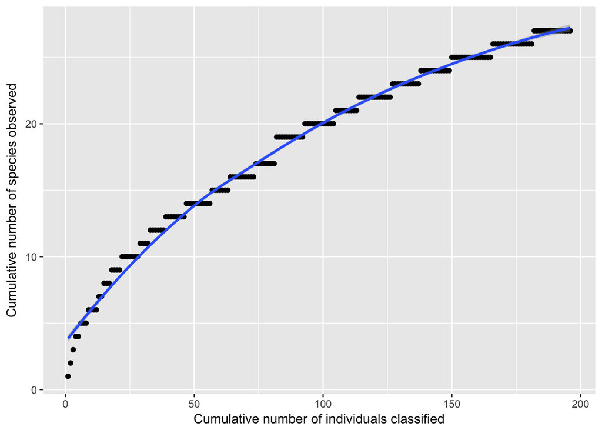

```r
example_data2 = data.frame(
  x = c(1,2,3,4,5,6,7,8,9,10,11,12,13,14,15,16,17,18,19,20,21,22,23,24,25,26,27,28,29,30,31,32,33,34,35,36,37,38,39,40,41,42,43,44,45,46,47,48,49,50,51,52,53,54,55,56,57,58,59,60,61,62,63,64,65,66,67,68,69,70,71,72,73,74,75,76,77,78,79,80,81,82,83,84,85,86,87,88,89,90,91,92,93,94,95,96,97,98,99,100,101,102,103,104,105,106,107,108,109,110,111,112,113,114,115,116,117,118,119,120,121,122,123,124,125,126,127,128,129,130,131,132,133,134,135,136,137,138,139,140,141,142,143,144,145,146,147,148,149,150,151,152,153,154,155,156,157,158,159,160,161,162,163,164,165,166,167,168,169,170,171,172,173,174,175,176,177,178,179,180,181,182,183,184,185,186,187,188,189,190,191,192,193,194,195,196),
  y = c(1,2,3,4,4,5,5,5,6,6,6,6,7,7,8,8,8,9,9,9,9,10,10,10,10,10,10,10,11,11,11,11,12,12,12,12,12,12,13,13,13,13,13,13,13,13,14,14,14,14,14,14,14,14,14,14,15,15,15,15,15,15,15,16,16,16,16,16,16,16,16,16,16,17,17,17,17,17,17,17,17,19,19,19,19,19,19,19,19,19,19,19,20,20,20,20,20,20,20,20,20,20,20,20,21,21,21,21,21,21,21,21,21,22,22,22,22,22,22,22,22,22,22,22,22,22,23,23,23,23,23,23,23,23,23,23,23,24,24,24,24,24,24,24,24,24,24,24,24,25,25,25,25,25,25,25,25,25,25,25,25,25,25,25,25,26,26,26,26,26,26,26,26,26,26,26,26,26,26,26,26,27,27,27,27,27,27,27,27,27,27,27,27,27,27,27)
)

ggplot(example_data2, aes(x=x, y=y)) +
  geom_point() +
  geom_smooth() +
  labs(x="Cumulative number of individuals classified", y="Cumulative number of species observed")
```

- Does the curve flatten out? If so, after how many individual cells have been collected?

- What can you conclude from the shape of your collector’s curve as to your depth of sampling?

#### Part 3: Diversity estimates (alpha diversity)

Using the table from Part 1, calculate species diversity using the following indices or metrics.

##### Diversity: Simpson Reciprocal Index

$\frac{1}{D}$ where $D = \sum p_i^2$

$p_i$ = the fractional abundance of the $i^{th}$ species

For example, using the example data 1 with 3 species with 2, 4, and 1 individuals each, D =

```r
species1 = 2/(2+4+1)
species2 = 4/(2+4+1)
species3 = 1/(2+4+1)

1 / (species1^2 + species2^2 + species3^2)
```

```
## [1] 2.333333
```

- What is the Simpson Reciprocal Index for your sample?

```r
D=
BigBallsGreen = 1/196
BigBallsBrown  = 1/196
BigBallsYellow = 1/196
MMBrown=15/196
MMRed=8/196
MMGreen=9/196
MMBlue=2/196
MMOrange=17/196
MMYellow=8/196
SkittlesBrown=9/196
SkittlesRed=10/196
SkittlesGreen=12/196
SkittlesBlue=10/196
SkittlesOrange=7/196
SkittlesYellow=7/196
MikesIkeYellow=10/196
MikesIkeRed=4/196
MikesIkeGreen=14/196
MikesIkeOrange=12/196
GummyBearsRed=9/196
GummyBearsYellow=10/196
GummyBearsGreen=7/196
BricksPink=2/196
BricksYellow=3/196
HersheyKiss=2/196
RedSnakes=1/196
Chocolate=5/196

1 / (BigBallsGreen^2 + BigBallsBrown^2 + BigBallsYellow^2+BricksPink^2+BricksYellow^2+Chocolate^2+GummyBearsGreen^2+GummyBearsRed^2+GummyBearsYellow^2+HersheyKiss^2+MikesIkeGreen^2+MikesIkeOrange^2+MikesIkeRed^2+MikesIkeYellow^2+MMBlue^2+MMBrown^2+MMGreen^2+MMOrange^2+MMRed^2+MMYellow^2+RedSnakes^2+SkittlesBlue^2+SkittlesBrown^2+SkittlesGreen^2+SkittlesOrange^2+SkittlesRed^2+SkittlesYellow^2)
```

```
## [1] 19.38244
```

- What is the Simpson Reciprocal Index for your original total community?

```r
RIGOAMaroon=2/799
RIGOAYellow=1/799
RIGOTranslucent=2/799
RIGOAOrange=1/799
RIGOABrown=1/799
SkittlesBrown2=37/799
SkittlesYellow2=35/799
SkittlesRed2=43/799
SkittlesOrange2=37/799
SkittlesGreen2=45/799
MMBrown=30/799
MMRed=28/799
MMGreen=24/799
MMBlue=39/799
MMOrange2=65/799
MMYellow=32/799
MIYellow=45/799
MIPik=44/799
MIRed=41/799
MIGreen=39/799
MIOrange=30/799
GBPink=17/799
GBRed=11/799
GBGreen=17/799
GBOrange=15/799
GBYellow=17/799
GBTranslucentYellow=14/799
LEGOBlueSquare=1/799
LEGOBlueRectangle=3/799
LEGOGreenRectangle=2/799
LEGOYellowSquare=1/799
LEGOYellowRectangle=4/799
LEGOPinkSquare=1/799
LEGOPinkRectange=6/799
GumdropBrownishPurple=3/799
GumdropsRed=7/799
GumdropsGreen=5/799
GumdropsOrange=5/799
GumdropsYellow=4/799
FruitShapeGumies=2/799
Macrophage=6/799
CokeBottle=3/799
BlueWhiteDrop=2/799
RedWhiteDrop=1/799
Watermelon=1/799
RedGreenFish=1/799
Kisses=16/799
RedSnakes=13/799

1/(RedSnakes^2+Kisses^2+RedGreenFish^2+Watermelon^2+RedWhiteDrop^2+BlueWhiteDrop^2+CokeBottle^2+Macrophage^2+FruitShapeGumies^2+GumdropsYellow^2+GumdropsOrange^2+GumdropsGreen^2+GumdropsRed^2+GumdropBrownishPurple^2+LEGOBlueRectangle^2+LEGOBlueSquare^2+LEGOGreenRectangle^2+LEGOPinkRectange^2+LEGOPinkSquare^2+LEGOPinkRectange^2+GBTranslucentYellow^2+GBYellow^2+GBOrange^2+GBGreen^2+GBRed^2+GBPink^2+MIOrange^2+MIGreen^2+MIRed^2+MIPik^2+MIYellow^2+MMOrange2^2+MMBlue^2+MMGreen^2+MMRed^2+MMBrown^2+SkittlesGreen2^2+SkittlesOrange2^2+SkittlesRed2^2+SkittlesYellow2^2+SkittlesBrown2^2+RIGOABrown^2+RIGOAOrange^2+RIGOTranslucent^2+RIGOAYellow^2+RIGOAMaroon^2)
```

```
## [1] 24.5369
```

##### Richness: Chao1 richness estimator

Another way to calculate diversity is to estimate the number of species that are present in a sample based on the empirical data to give an upper boundary of the richness of a sample. Here, we use the Chao1 richness estimator.

$S_{chao1} = S_{obs} + \frac{a^2}{2b})$

$S_{obs}$ = total number of species observed a = species observed once b = species observed twice or more

So for our previous example community of 3 species with 2, 4, and 1 individuals each, $S_{chao1}$ =

```r
3 + 1^2/(2*2)
```

```
## [1] 3.25
```

- What is the chao1 estimate for your sample?

```r
27+4^2/(2*23)
```

```
## [1] 27.34783
```

- What is the chao1 estimate for your original total community?

```r
48+9^2/(2*39)
```

```
## [1] 49.03846
```

#### Part 4: Alpha-diversity functions in R

We’ve been doing the above calculations by hand, which is a very good exercise to aid in understanding the math behind these estimates. Not surprisingly, these same calculations can be done with R functions. Since we just have a species table, we will use the `vegan` package. You will need to install this package if you have not done so previously.

```r
library(vegan)
```

In Project 1, you will also see functions for calculating alpha-diversity in the `phyloseq` package since we will be working with data in that form.

- What are the Simpson Reciprocal Indices for your sample and community using the R function? My Sample:

```r
example_data1=data.frame(
  number = c(1,2,3,4,5,6,7,8,9,10,11,12,13,14,15,16,17,18,19,20,21,22,23,24,25,26,27),
  name = c("Big Balls", "Big Balls", "Big Balls","M&M","M&M","M&M","M&M","M&M","M&M","Skittles","Skittles","Skittles","Skittles","Skittles","Skittles","Mikes & Ike's","Mikes & Ike's","Mikes & Ike's","Mikes & Ike's","Gummy Bears","Gummy Bears","Gummy Bears","Bricks","Bricks","Hershey Kiss","Red Snakes","Chocolate"),
  characteristics = c("Green", "Brown", "Yellow","Brown","Red","Green","Blue","Orange","Yellow","Brown","Red","Green","Blue","Orange","Yellow","Yellow","Red","Green","Orange","Red","Yellow","Green","Pink","Yellow","None","None","None"),
  occurences = c(1,1,1,15,8,9,2,17,8,9,10,12,10,7,7,10,4,14,12,9,10,7,2,3,2,1,5)
)

example_data1 %>%
  kable("html") %>%
  kable_styling(bootstrap_options = "striped", font_size = 10, full_width = F)
```

| number | name | characteristics | occurences |
| --- | --- | --- | --- |
| 1 | Big Balls | Green | 1 |
| 2 | Big Balls | Brown | 1 |
| 3 | Big Balls | Yellow | 1 |
| 4 | M&M | Brown | 15 |
| 5 | M&M | Red | 8 |
| 6 | M&M | Green | 9 |
| 7 | M&M | Blue | 2 |
| 8 | M&M | Orange | 17 |
| 9 | M&M | Yellow | 8 |
| 10 | Skittles | Brown | 9 |
| 11 | Skittles | Red | 10 |
| 12 | Skittles | Green | 12 |
| 13 | Skittles | Blue | 10 |
| 14 | Skittles | Orange | 7 |
| 15 | Skittles | Yellow | 7 |
| 16 | Mikes & Ike’s | Yellow | 10 |
| 17 | Mikes & Ike’s | Red | 4 |
| 18 | Mikes & Ike’s | Green | 14 |
| 19 | Mikes & Ike’s | Orange | 12 |
| 20 | Gummy Bears | Red | 9 |
| 21 | Gummy Bears | Yellow | 10 |
| 22 | Gummy Bears | Green | 7 |
| 23 | Bricks | Pink | 2 |
| 24 | Bricks | Yellow | 3 |
| 25 | Hershey Kiss | None | 2 |
| 26 | Red Snakes | None | 1 |
| 27 | Chocolate | None | 5 |

```r
example_data1_diversity =
  example_data1 %>%
  select(number, occurences) %>%
  spread(number, occurences)

diversity(example_data1_diversity, index="invsimpson")
```

```
## [1] 19.38244
```

```r
specpool(example_data1_diversity)
```

```
##     Species chao chao.se jack1 jack1.se jack2 boot boot.se n
## All      27   27       0    27        0    27   27       0 1
```

My Commmunity:

```r
example_data2_diversity =
  example_data3 %>%
  select(number, occurences) %>%
  spread(number, occurences)
example_data2_diversity
```

```
##   1 2 3 4 5  6  7  8  9 10 11 12 13 14 15 16 17 18 19 20 21 22 23 24 25 26
## 1 2 1 2 1 1 37 35 43 37 45 30 28 24 39 65 32 45 44 41 39 30 17 11 17 15 17
##   27 28 29 30 31 32 33 34 35 36 37 38 39 40 41 42 43 44 45 46 47 48
## 1 14  1  3  2  1  4  1  6  3  7  5  5  4  2  6  3  2  1  1  1 16 13
```

```r
diversity(example_data2_diversity, index="invsimpson")
```

```
## [1] 23.62436
```

```r
specpool(example_data2_diversity)
```

```
##     Species chao chao.se jack1 jack1.se jack2 boot boot.se n
## All      48   48       0    48        0    48   48       0 1
```

- What are the Simpson Reciprocal Indices for your sample and community using the R function?

My Sample:19.38244

Community:23.62436

- What are the chao1 estimates for your sample and community using the R function?

My Sample:27

Community:48

```
+ Verify that these values match your previous calculations.
```

The Sample values for Simpson Reciprocal Indices and chao1 estimated matches the previous calculation well. The Community values for Simpson Reciprocal Indices and chao1 estimated do not exactly matched the previous calculation, but are very closed approximation and are only off by a value of 1.

#### Part 5: Concluding activity

If you are stuck on some of these final questions, reading the [Kunin et al. 2010](https://www.ncbi.nlm.nih.gov/pubmed/19725865) and [Lundin et al. 2012](https://www.ncbi.nlm.nih.gov/pubmed/23760801) papers may provide helpful insights.

- How does the measure of diversity depend on the definition of species in your samples?

Measure of diversity is dependent on numbers of species in each sample, therefore, depending on how you define species, types of species and numbers of samples in each species can be different. This in turns gives a different diversity values.

- Can you think of alternative ways to cluster or bin your data that might change the observed number of species?

In this set of data, our group has decided to group species accorrding to both texture and colour. So if we decide to group species only according to their textures or colours, numbers and types of species will be different and greatly reduced. Therefore, depending on how we characterize species, we will cluster or bin the data using an entire different sets of values.

- How might different sequencing technologies influence observed diversity in a sample?

Above examples have presented that diversity can be measured using both Simpson Reciprocal Indices and Chao1 richness estimator, and aboved calculation (From Part 3 and Part 4) has showned how those two measurements are obtained and those two technologies have given different D values.

## Evidence WorkSheet_5 “Extensive mosaic structure”

### Part 1

### Learning Objectives

- Evaluate the concept of microbial species based on environmental surveys and cultivation studies.
- Explain the relationship between microdiversity, genomic diversity and metabolic potential
- Comment on the forces mediating divergence and cohesion in natural microbial communities

[Welch, R. A.et al, 2002](https://www.ncbi.nlm.nih.gov/pubmed/12471157)

### General Questions:

#### What were the main questions being asked?

How does genomes of uropathogenic Escherichia coli compared with each other and what makes each genome distinct?

#### What were the primary methodological approaches used?

CFT073 (serotype O6:H1:K) was first isolated at the University of Maryland Hospital. Random clones were sequenced by using dye-terminator chemistry and data collected on Applied Biosystems ABI377 and 3700 automated sequencers.

The genome sequence was annotated in the multiuser, web-based annotation environment called MAGPIE. Predicted proteins were searched against the nonredundant database by using BLAST.

Therefore, the main methologies used are first cloning and sequencing the E.coli isolates, and then sequence analysis the genome sequence using multiuser, web-based annotation environment called MAGPIE.

#### Summarize the main results or findings.

-It is found out that genes in most part of E.coli chromosome are newly introduced via numerous, independent horizontal gene-transfer events at many discrete sites, some serving as universal insertion targets used independently in separate lineages. The net result is a mosaic genome structure in which newly acquired genes in each of the E. coli types are placed into a framework made of genes that distinguishes E. coli from its closer relatives such as S. enterica.

-Pathogenicity island concept based on the genetic behavior, virulence gene linkage relationships, and location of unique inserts near several tRNA genes. Evidences found in the study has suggested that extraintestinal E. coli may be oligoclonal despite the apparent linkage relationships of a handful of virulence genes and suggests that the uropathogenic E. coli may be as diverse as the intestinal strains.

-The presence of three extra homologues of the fimBE-like recombinases suggests that the DNA segment-inversion mech- anism of genetic phase variation may operate at regions other than the type I fimbrial adhesin in CFT073.

-The common core chromosome of the E. coli genomes has been preserved throughout its vertical evolution, with very limited intragenomic rearrangement, resulting in the conserved synteny apparent today.

#### Do new questions arise from the results?

First, this paper has pointed out ambuiguity between species in such we can reconsider how species should be defined and what constitute as a species.

Deletions that remove genes detrimental to the uropathogenic lifestyle is difficult to assess at this time because of the large number of genetic differences already observed, and additional *E.coli* genome sequences needed for comparisons.Therefore, this might be a question that required further investigations.

#### Were there any specific challenges or advantages in understanding the paper (e.g. did the authors provide sufficient background information to understand experimental logic, were methods explained adequately, were any specific assumptions made, were conclusions justified based on the evidence, were the figures or tables useful and easy to understand)?

Figures presented with various genome structure is pretty clear. Pathogenic island containing locations of various genes is also clearly showed. In such that result analyzing using sequence analysis technology is clearly portrayed in the diagram, and location of genes is mapped.

I am having troubles understanding methologies used to compare genome, condon sequences and relevant genes within the pathogencity island. Perhaps because I am lacking background knowledge regarding function of specific genes, I find difficult following the discussion when the author disscused various genes usage. I am also feeling a bit confused when the author is comparing different types of pathogenicity island. I am able to understand the big picture regarding how pathogenicity island are distributed and contributed to distribution of species, but I have trouble understanding details of specific genes and how those genes are located in specific parts of pathogenicity island, and how those genes contributed to its function

### Part 2

### Learning Objectives:

• Comment on the creative tension between gene loss, duplication and acquisition as it relates to microbial genome evolution

• Identify common molecular signatures used to infer genomic identity and cohesion

• Differentiate between mobile elements and different modes of gene transfer

Different ecotypes of bacteria adapt to different environmental pressures; different species diverges, and adapts to different environment and such divergence is crucial for species survival. Genes transfer are observed between species of bacteria, and in which large genes are difficult to transfer, and small genes can be transferred via horizontal or vertical transformation.

### Module 03 references:

Welch, R. A., Burland, V., Plunkett, G. I. I. I., Redford, P., Roesch, P., Rasko, D., … & Stroud, D. (2002). Extensive mosaic structure revealed by the complete genome sequence of uropathogenic Escherichia coli. Proceedings of the National Academy of Sciences, 99(26), 17020-17024. 12471157